# Transit and Employment Accessibility in the Omaha–Council Bluffs Study Region

Abhijith Reddy | IDS Team Project

October 2026

# 1 Research question and main finding

**Research question:** How does the prevalence of households without a vehicle relate to available transit service and employment accessibility across the three-county Omaha–Council Bluffs study region?

**Main finding:** Among census block groups with usable transit indicators, transit service generally appears concentrated in places where car-free households are more common. However, this overall pattern conceals **47 higher-car-free block groups with comparatively limited modeled transit access to employment**. These are *candidates for further investigation* using current GTFS schedules, ridership, and local transit-service data, rather than confirmed service gaps.

# 2 Methods

## 2.1 Study area, data source, and preparation

We use the team’s filtered EPA Smart Location Database (SLD), version 3 (released in 2021), covering **Douglas and Sarpy counties, Nebraska**, and **Pottawattamie County, Iowa**. The selection includes some places outside Omaha and Council Bluffs municipal limits. The unit of analysis is a **census block group**, not an individual household.

We load the county-filtered CSV, convert key variables to numeric, treat the EPA missing/noncoverage code `-99999` as unavailable (never as numeric zero), and reconstruct **candidate** 12-digit block-group identifiers from separately retained geographic components. The original `GEOID10` and `GEOID20` columns in the supplied export are truncated/rounded; reconstructed IDs must be validated against official boundaries before mapping.

```r
# Keep the CSV at the repository root (one directory above abhijith).
paths <- c(
  "../EPA_SDL_OmahaCouncilBluffs.csv",
  "EPA_SDL_OmahaCouncilBluffs.csv",
  "../EPA_SDL_OmahaCouncilBluffs(1).csv",
  "EPA_SDL_OmahaCouncilBluffs(1).csv"
)
available <- paths[file.exists(paths)]
if (length(available) == 0) {
  stop("EPA_SDL_OmahaCouncilBluffs.csv not found. Place it in the repository root.")
}

d <- read.csv(available[1], stringsAsFactors = FALSE,
              colClasses = c(STATEFP = "character", COUNTYFP = "character",
                             TRACTCE = "character", BLKGRPCE = "character",
                             GEOID10 = "character", GEOID20 = "character"))
stopifnot(nrow(d) > 0, all(c("Pct_AO0", "D4A", "D4C", "D4D", "D5BR", "D5AR", "HH", "AutoOwn0") %in% names(d)))

num_vars <- c("Pct_AO0", "D4A", "D4C", "D4D", "D5BR", "D5AR", "HH", "AutoOwn0")
for (v in num_vars) {
  d[[v]] <- as.numeric(d[[v]])
  d[[v]][d[[v]] == -99999] <- NA_real_
}

# Uploaded CSV has truncated/rounded GEOID10 and GEOID20 fields.
# Reconstruct *candidate* 12-character block group IDs from intact components.
d$block_group_id_reconstructed <- paste0(
  sprintf("%02d", as.integer(d$STATEFP)),
  sprintf("%03d", as.integer(d$COUNTYFP)),
  sprintf("%06d", as.integer(d$TRACTCE)),
  sprintf("%01d", as.integer(d$BLKGRPCE))
)
stopifnot(length(unique(d$block_group_id_reconstructed)) == nrow(d))

d$county <- ifelse(d$STATEFP == "31" & as.integer(d$COUNTYFP) == 55, "Douglas",
            ifelse(d$STATEFP == "31" & as.integer(d$COUNTYFP) == 153, "Sarpy",
            ifelse(d$STATEFP == "19" & as.integer(d$COUNTYFP) == 155, "Pottawattamie", NA)))
stopifnot(!anyNA(d$county))
d$carfree_pct <- 100 * d$Pct_AO0
threshold <- as.numeric(quantile(d$Pct_AO0, probs = 0.75, na.rm = TRUE))
d$higher_carfree <- !is.na(d$Pct_AO0) & d$Pct_AO0 >= threshold
jobs_median <- median(d$D5BR, na.rm = TRUE)
d$relative_gap_flag <- d$higher_carfree & !is.na(d$D5BR) & d$D5BR < jobs_median
```

## 2.2 Measures and interpretation

| EPA field | What is measured | How it is interpreted |
| --- | --- | --- |
| `Pct_AO0` | Share of households with **no vehicle** | A 0–1 proportion; multiplied by 100 to display percent |
| `D4A` | Network walking distance to the nearest qualifying transit stop (meters) | Lower means closer stop proximity **among observed records** |
| `D4C` | Aggregate afternoon peak-period transit-service frequency | Higher means more reported service frequency |
| `D4D` | Transit service-frequency density per square mile | Higher means denser reported service |
| `D5BR` | Time-decay-weighted employment accessibility by public transit, under EPA’s modeled travel assumptions | Higher means greater modeled transit job accessibility; **not** a count of every job directly reachable |
| `D5AR` | Time-decay-weighted employment accessibility by automobile | Higher means greater modeled access by auto, under a different mode/travel-time model |

Definitions and source conventions follow the EPA Smart Location Database documentation linked in *Sources* below. The automobile and transit job-access measures should **not** be divided to obtain a literal percentage of the same jobs accessible within identical door-to-door trip times.

## 2.3 Missing-value handling and analytic sample

A `-99999` value is treated as *unavailable* for that indicator. For some variables, it may reflect distance-threshold rules, incomplete GTFS-based transit coverage, or other noncoverage conditions. It is **not** evidence of zero transit service or zero accessible jobs. Each correlation, median, and visualization uses **only valid observations for the indicator involved**; denominators may therefore differ.

In particular, D5BR is measured for just **362 of 727** block groups, including only **1 of 93** Pottawattamie block groups. **We do not use missing Iowa-side values as zeros or attempt a direct Omaha–Council Bluffs transit-access comparison.** Coverage is reported as a result before any substantive interpretation.

## 2.4 Associations and group comparison

We calculate **Spearman rank correlations** of zero-vehicle household share (`Pct_AO0`) with each transit or employment-accessibility measure. This describes the direction of a monotonic association among observed block groups, without assuming linearity or establishing causation.

We compare the **observed indicator medians** between (a) block groups at or above the 75th percentile of the full-sample car-free household share and (b) remaining block groups. The **higher-car-free cutoff** is calculated once from all 727 study-area block groups: **8.68%** (the upper quartile). This is a descriptive grouping, not a policy benchmark.

## 2.5 Relative-gap screening definition

A block group is a *relative transit-employment-access gap candidate* **only if both** of these conditions apply:

1. Its car-free share is **at or above 8.68%**, the full-sample upper quartile; and
2. Its **observed** `D5BR` score is **below 9,975**, the median of available transit-job scores in the study file.

Block groups with missing D5BR are **not screened or flagged as low-access**. The resulting flag is a project-defined, dataset-relative prioritization device, **not an official transit-service or planning standard**; it does not establish service insufficiency or identify a formal transit desert.

# 3 Results

## 3.1 Figure 1 — Uneven availability of transit indicators

```r
counties <- c("Douglas", "Sarpy", "Pottawattamie")
coverage <- do.call(rbind, lapply(counties, function(nm) {
  x <- d[d$county == nm, ]
  data.frame(
    County = nm,
    `Block groups` = nrow(x),
    `D4A valid` = sum(!is.na(x$D4A)),
    `D4C valid` = sum(!is.na(x$D4C)),
    `D5BR valid` = sum(!is.na(x$D5BR)),
    check.names = FALSE
  )
}))
knitr::kable(coverage, caption = "Availability of key transit measures by county")
```

Availability of key transit measures by county

| County | Block groups | D4A valid | D4C valid | D5BR valid |
| --- | --- | --- | --- | --- |
| Douglas | 497 | 341 | 265 | 341 |
| Sarpy | 137 | 20 | 23 | 20 |
| Pottawattamie | 93 | 1 | 3 | 1 |

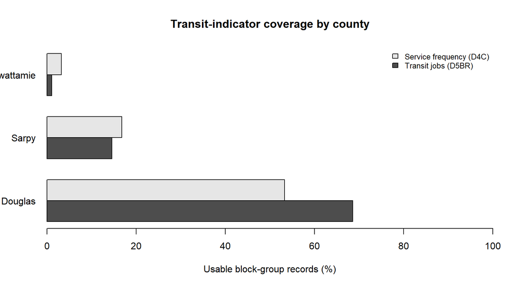

**What the figure shows.** Transit-based indicator coverage differs sharply by county. D5BR is observed for **362 of 727** block groups overall, including only **1 of 93** in Pottawattamie County. The bars describe *data availability*, **not** the presence or absence of service.

**Why this matters.** A county with fewer reported transit observations should not automatically be described as having worse transit. A comparison based on the available D5BR values would disproportionately represent the Nebraska side.

**Planner use.** Before choosing investment locations or comparing jurisdictions, obtain current, consistent GTFS, service-coverage and ridership information for **both sides** of the metro area, and examine whether omitted block groups are systematically different from observed ones.

## 3.2 Overall associations: correlation table

```r
indicators <- c("D4A", "D4C", "D4D", "D5BR", "D5AR")
comparison <- do.call(rbind, lapply(indicators, function(var) {
  valid <- !is.na(d[[var]]) & !is.na(d$Pct_AO0)
  data.frame(
    Indicator = var,
    `Observed n` = sum(valid),
    `Spearman rho` = round(cor(d$Pct_AO0[valid], d[[var]][valid], method = "spearman"), 3),
    `Higher-car-free median` = round(median(d[[var]][valid & d$higher_carfree]), 1),
    `Other median` = round(median(d[[var]][valid & !d$higher_carfree]), 1),
    check.names = FALSE
  )
}))
knitr::kable(comparison, caption = "Observed associations and group comparisons")
```

Observed associations and group comparisons

| Indicator | Observed n | Spearman rho | Higher-car-free median | Other median |
| --- | --- | --- | --- | --- |
| D4A | 362 | -0.264 | 379.5 | 505.6 |
| D4C | 291 | 0.334 | 3.0 | 1.3 |
| D4D | 291 | 0.372 | 15.4 | 5.3 |
| D5BR | 362 | 0.257 | 29142.0 | 6031.0 |
| D5AR | 727 | 0.218 | 84132.0 | 75210.0 |

Among measured block groups, car-free share is positively associated with transit-job accessibility (Spearman **ρ = 0.257**), positively associated with peak-service frequency (**ρ = 0.334**), and negatively associated with distance to the nearest qualifying stop (**ρ = -0.264**; shorter distances are more favorable). These are associations among observed records, not causal effects.

## 3.3 Figure 2 — Car-free share versus transit access to jobs

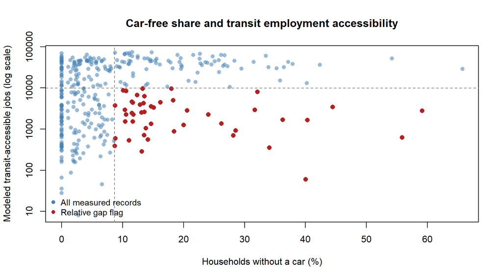

**What the figure shows.** The overall positive association between car-free share and modeled transit-job accessibility coexists with observations in the lower-right region of the plot: higher-car-free block groups with below-median measured job access. The dashed vertical and horizontal lines show the two *relative* screening thresholds; the vertical axis uses a logarithmic scale.

**Why this matters.** A favorable regional correlation can hide pockets of potential need. Transit proximity or service concentrated in car-free neighborhoods at a regional scale does not guarantee that every such neighborhood can reach many jobs by transit.

**Planner use.** Use the flagged observations as an **initial shortlist** for investigating job destinations, transit route connections, frequency, wait times and transfer burden—then verify with contemporary route and ridership information.

## 3.4 Figure 3 — Car-free share versus distance to transit stops

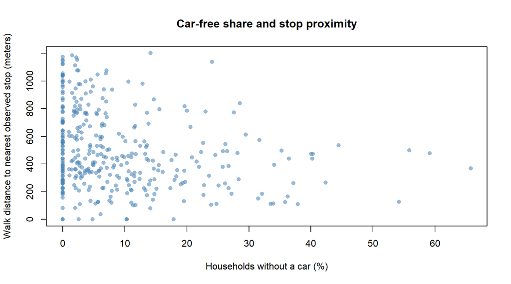

**What the figure shows.** Among block groups with an observed D4A value, higher car-free shares generally correspond to shorter walking distances to a qualifying stop (negative Spearman association). Individual block groups vary substantially around that trend.

**Why this matters.** Access to a nearby stop is one part of mobility, but it does **not** measure how often vehicles arrive or which jobs they reach.

**Planner use.** Compare distance-based findings with actual peak and off-peak timetables, safe walking routes, ADA accessibility and bus-stop conditions when prioritizing local improvements.

## 3.5 Figure 4 — Differences and variation in transit-based employment access

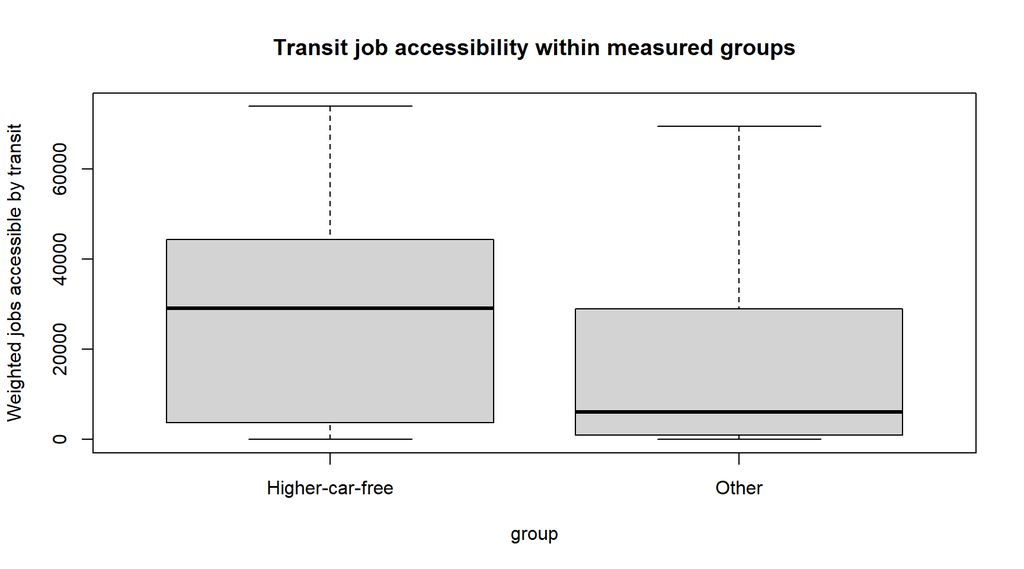

**What the figure shows.** The measured higher-car-free group has a median **29,142** weighted transit-accessible jobs, compared with **6,031** for the other measured group. Both groups nonetheless show considerable variation. The boxplot suppresses outlier markers for readability but does not exclude those observations from reported statistics.

**Why this matters.** Group averages or medians can obscure within-group differences. The most useful planning targets may be specific places rather than an entire county or group.

**Planner use.** Combine the distribution and the candidate list with local factors such as employment centers, commuting times, equity goals, and neighborhood engagement instead of allocating resources based on one group median.

## 3.6 Figure 5 — Modeled access to employment: transit and auto

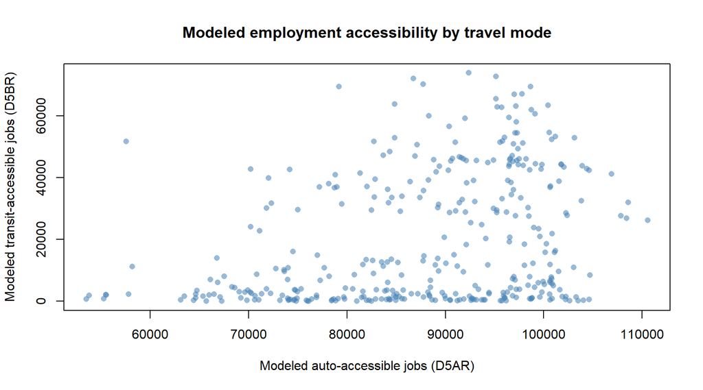

**What the figure shows.** The plotted block groups have observed values for both modeled automobile (`D5AR`) and public-transit (`D5BR`) job-access indicators. The measures vary across neighborhoods and are calculated under different travel-mode and time-decay assumptions.

**Why this matters.** This is a useful comparative view of **mode-specific accessibility**, but it is **not** a literal share of identical jobs accessible by transit versus car. Treating the plotted values as interchangeable would misstate the results.

**Planner use.** Look for places where transit accessibility merits closer evaluation alongside auto access; use common-origin, current-door-to-door travel-time analyses to make any formal mode-comparison or investment decision.

## 3.7 Relative-gap screening: 47 candidates

The two-condition screen identifies **47** block groups among **131** higher-car-free block groups with observed transit-job data (**35.9%** of that observed subset). This means **potential relative need**, not proven service inadequacy. The ten candidates with the lowest observed D5BR are listed below; the complete file is `results/relative_gap_candidates.csv`.

```r
cols <- c("block_group_id_reconstructed", "county", "carfree_pct", "D5BR", "D4A", "D4C")
gap <- d[d$relative_gap_flag, cols, drop = FALSE]
gap <- gap[order(gap$D5BR, -gap$carfree_pct), ]
show <- head(gap, 10)
show$carfree_pct <- round(show$carfree_pct, 1)
show$D4A <- round(show$D4A, 1)
names(show) <- c("Reconstructed ID", "County", "Car-free %", "Transit jobs", "Stop distance (m)", "Service frequency")
knitr::kable(show, caption = "Ten relative gap candidates with the lowest observed D5BR")
```

Ten relative gap candidates with the lowest observed D5BR

|  | Reconstructed ID | County | Car-free % | Transit jobs | Stop distance (m) | Service frequency |
| --- | --- | --- | --- | --- | --- | --- |
| 353 | 310550011001 | Douglas | 40.0 | 60 | 472.1 | NA |
| 288 | 310550065061 | Douglas | 13.2 | 288 | 563.3 | 2.00 |
| 257 | 310550063021 | Douglas | 34.1 | 356 | 393.0 | 1.00 |
| 268 | 310550064002 | Douglas | 8.7 | 389 | 445.2 | NA |
| 355 | 310550012001 | Douglas | 11.1 | 530 | 119.4 | NA |
| 275 | 310550065043 | Douglas | 14.1 | 557 | 1201.6 | 2.33 |
| 325 | 310550074513 | Douglas | 8.8 | 591 | 426.5 | NA |
| 354 | 310550011002 | Douglas | 55.9 | 627 | 498.9 | NA |
| 289 | 310550065062 | Douglas | 28.1 | 695 | 480.1 | 3.00 |
| 147 | 310550074361 | Douglas | 13.5 | 717 | 435.9 | NA |

**Why this matters for planning.** The 47 candidates offer a focused starting point for a finer-grained evaluation that a regional average would miss.

**Recommended next step.** Validate reconstructed census block-group IDs against an official geography file, then cross-check the shortlist with up-to-date GTFS schedules, ridership, travel-time-to-jobs estimates, local service changes and community input. Only after that verification should planners consider route redesign, frequency improvements, stop access or other investments.

# 4 Discussion, limitations, and team integration

**Core interpretation.** Transit service generally appears concentrated in neighborhoods where car-free households are more common **among observed records**, but this pattern hides **47 higher-car-free block groups with comparatively limited modeled transit access to employment**. These locations are candidates for further study, **not confirmed transit deserts**.

- **Uneven and incomplete coverage:** D5BR is observed for only 362 of 727 block groups; only **1 of 93** Pottawattamie observations has a usable D5BR value. Missing Iowa-side values **must not** be interpreted as zero service, and no direct Omaha–Council Bluffs D5BR comparison is warranted.
- **Historical scope:** EPA SLD v3 is a 2021 release based on historical transit, demographic and employment inputs; findings are **not** a measure of current (2026) transit conditions.
- **Modeled versus actual experience:** D5BR and D5AR are travel-model measures with different assumptions, not observed commuting outcomes. Service frequency does not capture reliability, fares, transfer quality or traveler needs.
- **Geography and ID quality:** The three-county area extends beyond city limits. The supplied geographic-ID fields are damaged; reconstructed candidate IDs need external confirmation before geospatial mapping or geographic policy action.
- **Descriptive—not causal:** Block-group correlations may reflect land use, housing cost, residential sorting, density and many other factors; the analysis does not establish that transit provision causes car ownership patterns.

**Connections to team sections:** Compare the 47 candidate flags with **Adithya’s neighborhood archetypes** and **Juicio’s vehicle-ownership prediction** to enrich interpretation. **Noah’s Omaha/Council Bluffs or Nebraska/Iowa comparison** should explicitly report the coverage imbalance and avoid inferring Iowa transit performance from unavailable GTFS-based scores.

# 5 Sources

- U.S. Environmental Protection Agency, *Smart Location Mapping*: https://www.epa.gov/smartgrowth/smart-location-mapping
- U.S. Environmental Protection Agency, *Smart Location Database Technical Documentation and User Guide, version 3.0 (2021)*: https://nepis.epa.gov/Exe/ZyPURL.cgi?Dockey=P1014W9I.TXT
- Project source: `EPA_SDL_OmahaCouncilBluffs.csv` (three-county filtered EPA SLD v3 dataset).